# Prediction Assignment

Xiaoyang Jin

2017-01-17

# Contents

## 0.1 Background

Using devices such as *Jawbone Up*, *Nike FuelBand*, and *Fitbit* it is now possible to collect a large amount of data about personal activity relatively inexpensively. These type of devices are part of the quantified self movement – a group of enthusiasts who take measurements about themselves regularly to improve their health, to find patterns in their behavior, or because they are tech geeks. One thing that people regularly do is quantify how *much* of a particular activity they do, but they rarely quantify *how well they do it*. In this project, your goal will be to use data from accelerometers on the belt, forearm, arm, and dumbell of 6 participants. They were asked to perform barbell lifts correctly and incorrectly in 5 different ways. More information is available from the website here: http://groupware.les.inf.puc-rio.br/har (see the section on the Weight Lifting Exercise Dataset).

The training data for this project are available here:

https://d396qusza40orc.cloudfront.net/predmachlearn/pml-training.csv

The test data are available here:

https://d396qusza40orc.cloudfront.net/predmachlearn/pml-testing.csv

## 0.2 Train and select models

### 0.2.1 preprocess

First we will read in the data, the training and testing data are already downloaded into the ‘data/’ directory.

```r
training <- read.csv("data/pml-training.csv",
                     na.strings = c("NA", ""),
                     stringsAsFactors = FALSE)
testing <- read.csv("data/pml-testing.csv",
                     na.strings = c("NA", ""),
                     stringsAsFactors = FALSE)
```

```r
dim(training)
```

```
## [1] 19622   160
```

```r
table(training$classe)
```

```
##
##    A    B    C    D    E
## 5580 3797 3422 3216 3607
```

As we see, the training dataset has a sample size of 19622, and there are 159 features in this dataset (that’s somehow a huge number compared to the sample size). The **classe** variable is what we would predict in the test set, and it seems balanced.

The data type of each feature will be estimated, lest it’s misjudged in `read.csv` function. (In fact, this step shows no effect when I inspect the change happened)

```r
for(i in seq(ncol(training)-1)) {
    vector_valid = training[,i][!is.na(training[,i]) & training[,i] != ""]
    if(length(vector_valid) == 0 ||
       sum(is.na(suppressWarnings(as.numeric(vector_valid)))) > 0) {
        training[,i] = as.character(training[,i])
        testing[,i] = as.character(testing[,i])
    } else {
        training[,i] = as.numeric(training[,i])
        testing[,i] = as.numeric(testing[,i])
    }
}
```

The first 7 columns will be removed because these variables shouldn’t relate to the result variable. Besides, as the number of features is large, we could safely remove all the features with missing values.

```r
training = training[,-c(1:7)]
testing = testing[,-c(1:7)]

column.complete = complete.cases(t(training))
training = training[, column.complete]
testing = testing[, column.complete]

dim(training)
```

```
## [1] 19622    53
```

After this process, 52 features remain in our dataset (the `training` data frame has 53 columns because one of them is the result variable).

Next the training set is cut apart into the de facto training part and the validation part. The validation part will be used to predict out of sample error before we turn to the real test set.

```r
library(caret)
set.seed(2017)

train.idx = createDataPartition(training$classe, p = 3/4, list = FALSE)
train_dat = training[train.idx,]
validate_dat = training[-train.idx,]
```

### 0.2.2 train model using rpart

Now we will train a decision tree model using `rpart` mothod. 5-fold cross validation is used in `train` function.

```r
library(rpart)
set.seed(2017)

model1 <- train(classe ~ ., data = train_dat,
                method = "rpart",
                trControl = trainControl(method = "cv", number = 5))
```

The final tree model could be plotted using the `fancyRpartPlot` function in `rattle` package:

```r
library(rattle)
```

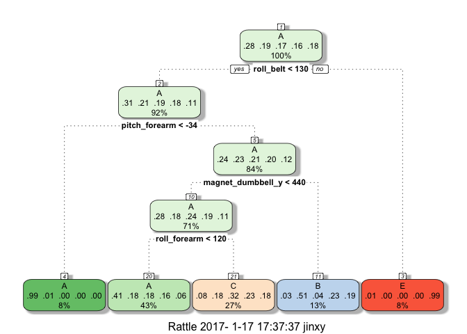

```r
fancyRpartPlot(model1$finalModel)
```

The out of sample error could be calculated on the validation set

```r
(model1_conf =
     confusionMatrix(predict(model1, newdata = validate_dat),
                     validate_dat$classe))
```

```
## Confusion Matrix and Statistics
##
##           Reference
## Prediction    A    B    C    D    E
##          A 1270  386  408  364  142
##          B   30  316   25  138  118
##          C   92  247  422  302  229
##          D    0    0    0    0    0
##          E    3    0    0    0  412
##
## Overall Statistics
##
##                Accuracy : 0.4935
##                  95% CI : (0.4794, 0.5076)
##     No Information Rate : 0.2845
##     P-Value [Acc > NIR] : < 2.2e-16
##
##                   Kappa : 0.3376
##  Mcnemar's Test P-Value : NA
##
## Statistics by Class:
##
##                      Class: A Class: B Class: C Class: D Class: E
## Sensitivity            0.9104  0.33298  0.49357   0.0000  0.45727
## Specificity            0.6295  0.92137  0.78513   1.0000  0.99925
## Pos Pred Value         0.4942  0.50399  0.32663      NaN  0.99277
## Neg Pred Value         0.9464  0.85200  0.88012   0.8361  0.89107
## Prevalence             0.2845  0.19352  0.17435   0.1639  0.18373
## Detection Rate         0.2590  0.06444  0.08605   0.0000  0.08401
## Detection Prevalence   0.5241  0.12785  0.26346   0.0000  0.08462
## Balanced Accuracy      0.7700  0.62717  0.63935   0.5000  0.72826
```

The overall accuracy is 0.4934747

### 0.2.3 train model using random forest

Alternatively, we could use the random forset model, which is the default method in the `train` function

```r
library(randomForest)
set.seed(2017)
model2 <- train(classe ~ ., data = train_dat,
                trControl = trainControl(method = "cv", number = 5))
```

Again, we assess the model performance on the validation set

```r
(model2_conf =
    confusionMatrix(predict(model2, validate_dat),
                    validate_dat$classe))
```

```
## Confusion Matrix and Statistics
##
##           Reference
## Prediction    A    B    C    D    E
##          A 1394   11    0    0    0
##          B    0  936    3    0    1
##          C    0    2  849   14    3
##          D    0    0    3  790    7
##          E    1    0    0    0  890
##
## Overall Statistics
##
##                Accuracy : 0.9908
##                  95% CI : (0.9877, 0.9933)
##     No Information Rate : 0.2845
##     P-Value [Acc > NIR] : < 2.2e-16
##
##                   Kappa : 0.9884
##  Mcnemar's Test P-Value : NA
##
## Statistics by Class:
##
##                      Class: A Class: B Class: C Class: D Class: E
## Sensitivity            0.9993   0.9863   0.9930   0.9826   0.9878
## Specificity            0.9969   0.9990   0.9953   0.9976   0.9998
## Pos Pred Value         0.9922   0.9957   0.9781   0.9875   0.9989
## Neg Pred Value         0.9997   0.9967   0.9985   0.9966   0.9973
## Prevalence             0.2845   0.1935   0.1743   0.1639   0.1837
## Detection Rate         0.2843   0.1909   0.1731   0.1611   0.1815
## Detection Prevalence   0.2865   0.1917   0.1770   0.1631   0.1817
## Balanced Accuracy      0.9981   0.9926   0.9941   0.9901   0.9938
```

The accuracy is 0.9908238, which is much higher than the `rpart` method, so we will use the random forest method on the test set.

We could inspect the variable importance of model2 (only the 10 most important variables are listed):

```r
library(dplyr)
```

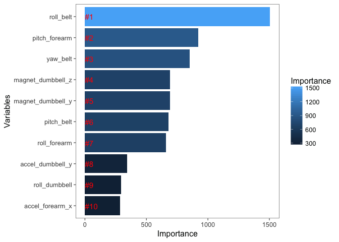

```r
library(ggplot2)
library(ggthemes)

# Get importance
importance    <- importance(model2$finalModel)
varImportance <- data.frame(Variables = row.names(importance),
                            Importance =
                                round(importance[,'MeanDecreaseGini'],2))

# Create a rank variable based on importance
rankImportance <- varImportance %>%
    top_n(10, Importance) %>%
    mutate(Rank = paste0('#',dense_rank(desc(Importance))))

# Use ggplot2 to visualize the relative importance of variables
ggplot(rankImportance, aes(x = reorder(Variables, Importance),
    y = Importance, fill = Importance)) +
  geom_bar(stat='identity') +
  geom_text(aes(x = Variables, y = 0.5, label = Rank),
    hjust=0, vjust=0.55, size = 4, colour = 'red') +
  labs(x = 'Variables') +
  coord_flip() +
  theme_few()
```

The first two most important variables are `roll_belt` and `pitch_forearm`, it’s in accordance with the previous tree model.

## 0.3 Predict on testing set

Now we could apply the model on the testing set

```r
predict(model2, newdata = testing)
```

```
##  [1] B A B A A E D B A A B C B A E E A B B B
## Levels: A B C D E
```

```
##  setting  value
##  version  R version 3.3.2 (2016-10-31)
##  system   x86_64, darwin13.4.0
##  ui       X11
##  language (EN)
##  collate  zh_CN.UTF-8
##  tz       Asia/Harbin
##  date     2017-01-17
```

```
## Packages ------------------------------------------------------------------
```

[output not shown]